# Bad Drivers in the United States

Nupur Sood

12/02/2021

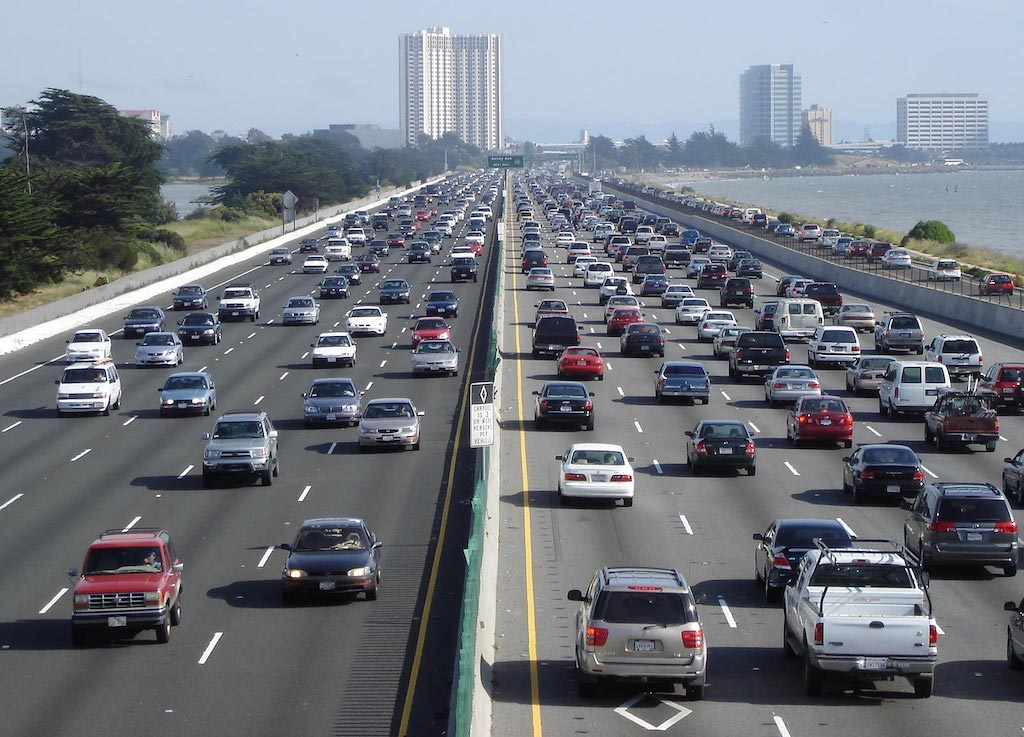

Picture source: [Wikipedia](https://en.wikipedia.org/wiki/Transportation_in_the_San_Francisco_Bay_Area#/media/File:I-80_Eastshore_Fwy.jpg)

## 1. Introduction

As a person living in the Silicon valley bay area for the last 5 years, I’ve always missed the better availability of public transport. That being said, driving a car is inevitable and necessary. I had a perfect driving record up until August this year when I was involved in a fender-bender just outside my garage! Although, the insurance covered it but it did feel bad to being in an “accident”. Accidents can happen even to the most careful among us and when accidents do happen, auto insurance is the only thing that can save us from a loto of personal liabilities which we are otherwise quite expensive. I have visited a few of the cities in the country and have seen a noticeable difference in driving style, driver tolerance and other factors. This piked my interest in exploring how different states in the USA compare to each other w.r.t driving quality and how drivers. We know car Insurance premium varies from driver to driver and there are lots of variables at work behind that, for example: age of the driver, driving record etc. We also pay higher or lower insurance depending on which state we live in. Can we predict the average insurance premiums for states from the driving record of that state.

## 2. Data

#### Data Source:

The data was collected from https://github.com/fivethirtyeight/data/tree/master/bad-drivers.

#### Variables:

1. State- Each state in United States
2. Number of drivers involved in fatal collisions per billion miles
3. Percentage Of Drivers Involved In Fatal Collisions Who Were Speeding
4. Percentage Of Drivers Involved In Fatal Collisions Who Were Alcohol-Impaired
5. Percentage Of Drivers Involved In Fatal Collisions Who Were Not Distracted
6. Percentage Of Drivers Involved In Fatal Collisions Who Had Not Been Involved In Any Previous Accidents
7. Car Insurance Premiums ($)
8. Losses incurred by insurance companies for collisions per insured driver ($)

#### Type of Study:

The study is observational and the data is collected based on what is seen without any interference. The data represents entire population of U.S. drivers. Thus, the data is generalized to the entire U.S. population.

```r
library(tidyverse)
```

#### Import data from the csv file:

```r
setwd("/Users/nupur/Downloads")
indata2 <- read.csv("/Users/nupur/Downloads/bad-drivers.csv")
indata2 <- as_tibble(indata2)
indata2
```

```
## # A tibble: 51 × 8
##    State                Number.of.drive… Percentage.Of.D… Percentage.Of.D… Percentage.Of.D…
##    <chr>                           <dbl>            <int>            <int>            <int>
##  1 Alabama                          18.8               39               30               96
##  2 Alaska                           18.1               41               25               90
##  3 Arizona                          18.6               35               28               84
##  4 Arkansas                         22.4               18               26               94
##  5 California                       12                 35               28               91
##  6 Colorado                         13.6               37               28               79
##  7 Connecticut                      10.8               46               36               87
##  8 Delaware                         16.2               38               30               87
##  9 District of Columbia              5.9               34               27              100
## 10 Florida                          17.9               21               29               92
## # … with 41 more rows, and 3 more variables:
## #   Percentage.Of.Drivers.Involved.In.Fatal.Collisions.Who.Had.Not.Been.Involved.In.Any.Previous.Accidents <int>,
## #   Car.Insurance.Premiums.... <dbl>,
## #   Losses.incurred.by.insurance.companies.for.collisions.per.insured.driver.... <dbl>
```

#### Data Cleanup

For ease of analysis, I have renamed all the column names to make the data frame more readable.

```r
# change column names to make them more readable
colnames(indata2) <- c('state', 'num_driver_fatal', 'percent_speeding', 'percent_alcohol',
                       'percent_not_distract', 'percent_no_previous', 'insur_prem', 'loss_per_insur_driver')
indata2
```

```
## # A tibble: 51 × 8
##    state                num_driver_fatal percent_speeding percent_alcohol percent_not_dis…
##    <chr>                           <dbl>            <int>           <int>            <int>
##  1 Alabama                          18.8               39              30               96
##  2 Alaska                           18.1               41              25               90
##  3 Arizona                          18.6               35              28               84
##  4 Arkansas                         22.4               18              26               94
##  5 California                       12                 35              28               91
##  6 Colorado                         13.6               37              28               79
##  7 Connecticut                      10.8               46              36               87
##  8 Delaware                         16.2               38              30               87
##  9 District of Columbia              5.9               34              27              100
## 10 Florida                          17.9               21              29               92
## # … with 41 more rows, and 3 more variables: percent_no_previous <int>,
## #   insur_prem <dbl>, loss_per_insur_driver <dbl>
```

#### Check for missing values in the dataset

```r
sum(is.na(indata2))
```

```
## [1] 0
```

#### Insights:

There are no missing observations in the dataset.

## 3. Exploratory Data Analysis

#### Which state has the highest number of drivers involved in fatal collisions per billion miles?

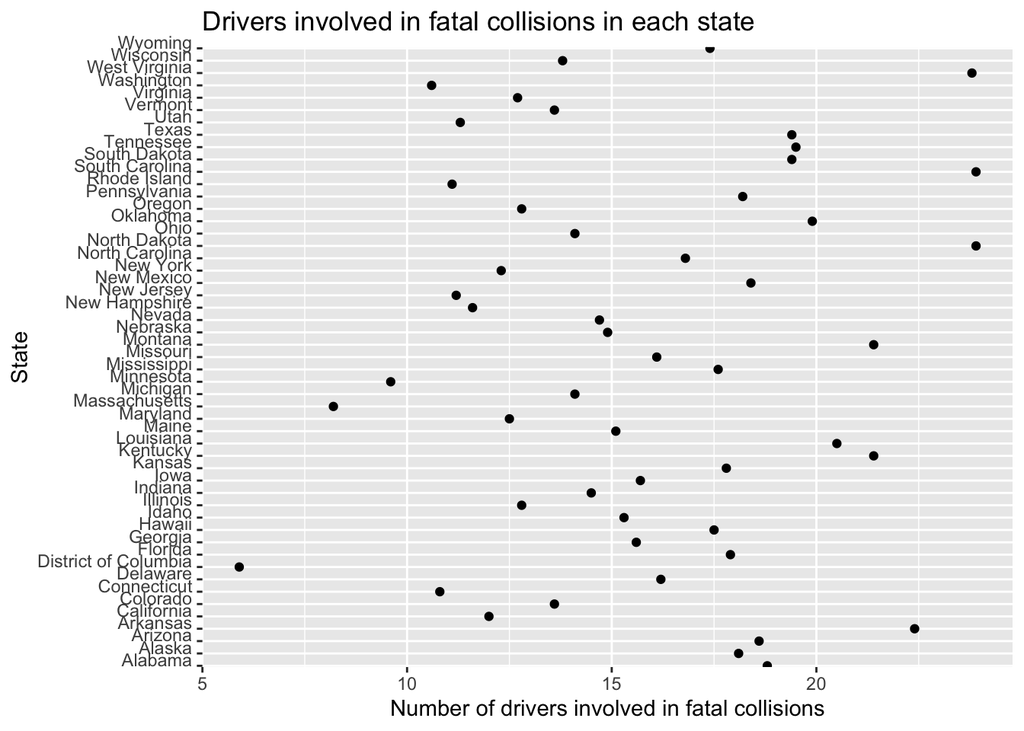

```r
plot1 <- ggplot(data = indata2) +
  geom_point(mapping = aes(x = num_driver_fatal, y = state)) + scale_y_discrete(expand=c(0.002, 0.002))

plot1+ labs(x = "Number of drivers involved in fatal collisions", y = "State",
                  title = "Drivers involved in fatal collisions in each state ") + theme(axis.text.y=element_text(angle=0,hjust=1,vjust=0))
```

#### Insights:

The plot shows us that North Dakota, South Carolina and West Virgina are the three states that have highest number of drivers involved in fatal collisions per billion miles.

#### Which state has the highest number of drivers involved in fatal collisions due to speeding?

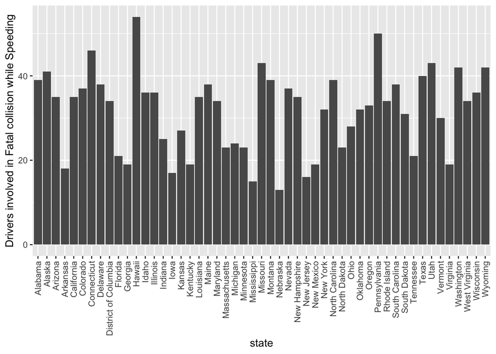

```r
 ggplot(indata2, aes(x = state,y = percent_speeding)) +
  geom_bar(position = "stack", stat="identity") +

  ylab("Drivers involved in Fatal collision while Speeding") +
  theme(axis.text.x=element_text(angle=90,hjust=1,vjust=0.5))
```

#### Insights:

The plot shows us that Hawaii has the highest percentage of drivers involved in fatal accidents due to over-speeding. Pennsylvania is next following state.

## 4. Data Analysis

#### Summarize data to get the population parameters of the data frame

```r
 summary(indata2)
```

```
##     state           num_driver_fatal percent_speeding percent_alcohol
##  Length:51          Min.   : 5.90    Min.   :13.00    Min.   :16.00
##  Class :character   1st Qu.:12.75    1st Qu.:23.00    1st Qu.:28.00
##  Mode  :character   Median :15.60    Median :34.00    Median :30.00
##                     Mean   :15.79    Mean   :31.73    Mean   :30.69
##                     3rd Qu.:18.50    3rd Qu.:38.00    3rd Qu.:33.00
##                     Max.   :23.90    Max.   :54.00    Max.   :44.00
##  percent_not_distract percent_no_previous   insur_prem
##  Min.   : 10.00       Min.   : 76.00      Min.   : 642.0
##  1st Qu.: 83.00       1st Qu.: 83.50      1st Qu.: 768.4
##  Median : 88.00       Median : 88.00      Median : 859.0
##  Mean   : 85.92       Mean   : 88.73      Mean   : 887.0
##  3rd Qu.: 95.00       3rd Qu.: 95.00      3rd Qu.:1007.9
##  Max.   :100.00       Max.   :100.00      Max.   :1301.5
##  loss_per_insur_driver
##  Min.   : 82.75
##  1st Qu.:114.64
##  Median :136.05
##  Mean   :134.49
##  3rd Qu.:151.87
##  Max.   :194.78
```

#### Convert fatalities into a Normal distribution after removing outlier

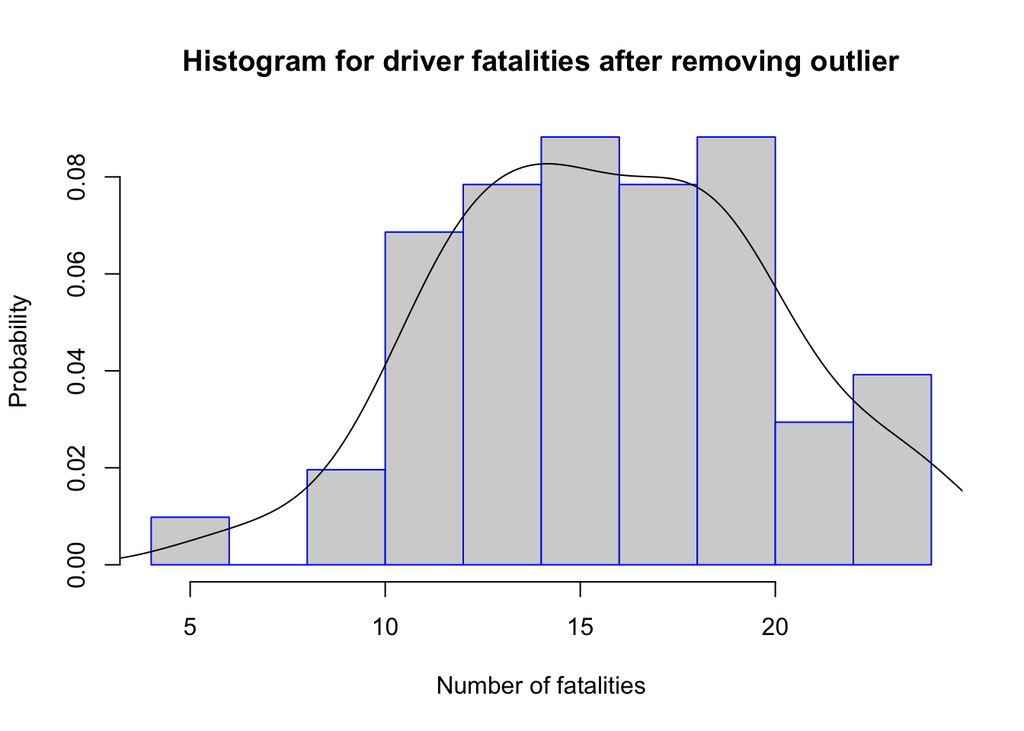

```r
 hist(indata2$num_driver_fatal, main="Histogram for driver fatalities after removing outlier",
     xlab="Number of fatalities", ylab= "Probability",
     border="blue", probability = T)
lines(density(indata2$num_driver_fatal))
```

#### Insights:

From the above histogram, we can see that the distribution of fatalities slightly skewed on the left, and follows slightly normal distribution. The outlier appears to be Washington DC. So we can remove DC from the dataset.

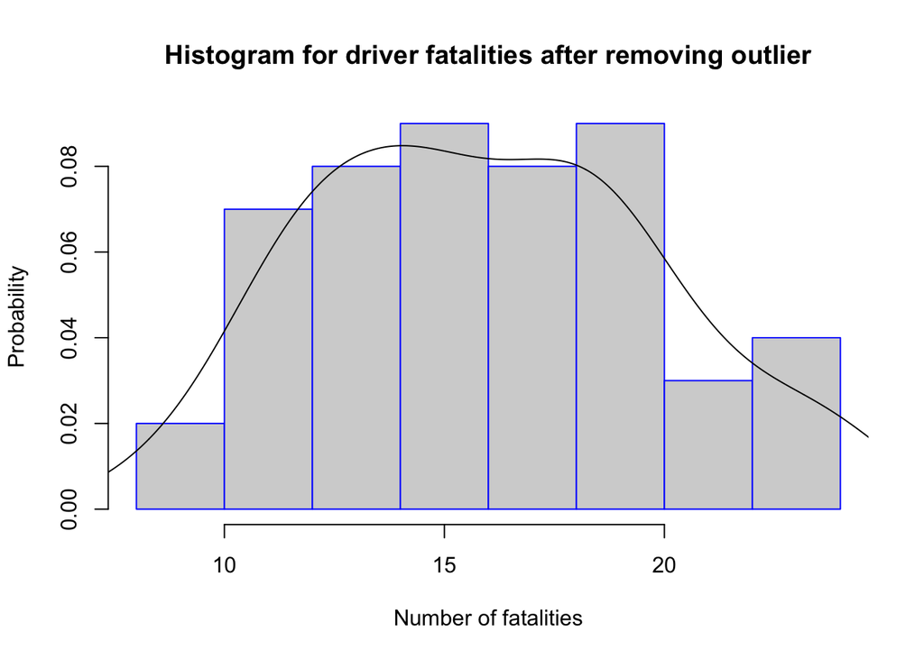

```r
indata3 <- indata2 %>% filter(`state` != "District of Columbia")

##var1 <- indata3$num_driver_fatal
h <- hist(indata3$num_driver_fatal,  main="Histogram for driver fatalities after removing outlier",
     xlab="Number of fatalities", ylab= "Probability",
     border="blue", probability = T)
lines(density(indata3$num_driver_fatal))
```

### Hypothesis testing for fatalities caused due to Speeding

```r
speeding <- indata2$percent_speeding
 mean_speeding <- mean(speeding)
 sd_percent_speeding <- sd(speeding)
 mean_speeding
```

```
## [1] 31.72549
```

```r
 sd_percent_speeding
```

```
## [1] 9.633438
```

```r
 t.test(speeding, mu= 30.5)
```

```
##
##  One Sample t-test
##
## data:  speeding
## t = 0.90848, df = 50, p-value = 0.368
## alternative hypothesis: true mean is not equal to 30.5
## 95 percent confidence interval:
##  29.01604 34.43494
## sample estimates:
## mean of x
##  31.72549
```

### Linear Regression model to find relation between insurance premiums and drivers involved in fatal collisions

```r
linreg1 <- lm(formula = insur_prem ~ num_driver_fatal, data = indata2)
summary(linreg1)
```

```
##
## Call:
## lm(formula = insur_prem ~ num_driver_fatal, data = indata2)
##
## Residuals:
##     Min      1Q  Median      3Q     Max
## -249.23 -136.43  -22.29  133.45  435.28
##
## Coefficients:
##                  Estimate Std. Error t value Pr(>|t|)
## (Intercept)      1023.354     98.748  10.363 6.08e-14 ***
## num_driver_fatal   -8.638      6.055  -1.427     0.16
## ---
## Signif. codes:  0 '***' 0.001 '**' 0.01 '*' 0.05 '.' 0.1 ' ' 1
##
## Residual standard error: 176.5 on 49 degrees of freedom
## Multiple R-squared:  0.03988,    Adjusted R-squared:  0.02029
## F-statistic: 2.035 on 1 and 49 DF,  p-value: 0.16
```

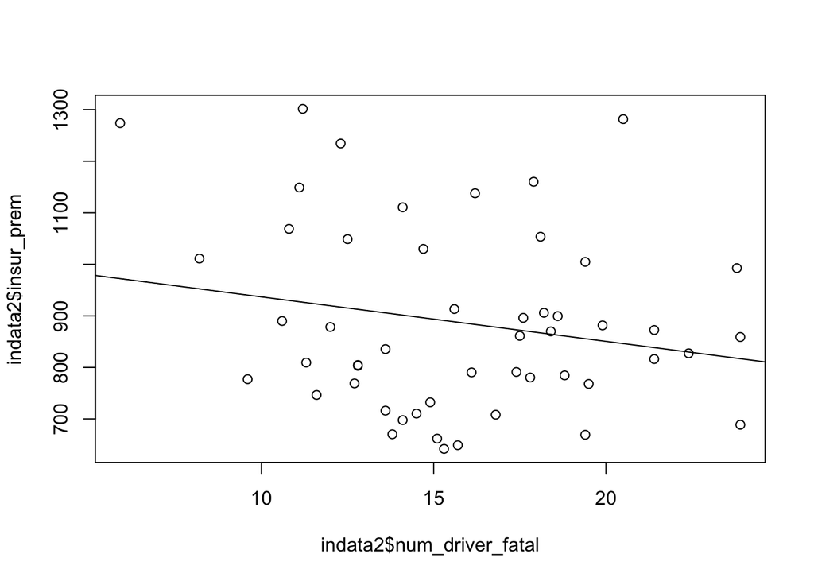

```r
plot(indata2$insur_prem ~ indata2$num_driver_fatal)
abline(linreg1)
```

```r
cor( indata2$insur_prem, indata2$num_driver_fatal)
```

```
## [1] -0.1997019
```

#### Insights:

If the number of drivers who are involved in a fatal collision per billion miles increase by 1 then the Insurance premium decreases by around $8.64. The variance of 3.99% of the response variable “Insurance premium” (insur_prem) can be explained by explanatory variable “Total fatal collisions” (num_driver_fatal). The plot above shows that there is a very weak (due to large deviance of datapoints from the line) negative linear relationship between the 2 variables.

### How does insurance company cover for their losses?

```r
linreg2 <- lm(formula = insur_prem ~ loss_per_insur_driver, data = indata2)
summary(linreg2)
```

```
##
## Call:
## lm(formula = insur_prem ~ loss_per_insur_driver, data = indata2)
##
## Residuals:
##     Min      1Q  Median      3Q     Max
## -213.33  -96.75  -40.11  112.24  379.97
##
## Coefficients:
##                       Estimate Std. Error t value Pr(>|t|)
## (Intercept)           285.3251   109.6689   2.602   0.0122 *
## loss_per_insur_driver   4.4733     0.8021   5.577 1.04e-06 ***
## ---
## Signif. codes:  0 '***' 0.001 '**' 0.01 '*' 0.05 '.' 0.1 ' ' 1
##
## Residual standard error: 140.9 on 49 degrees of freedom
## Multiple R-squared:  0.3883, Adjusted R-squared:  0.3758
## F-statistic:  31.1 on 1 and 49 DF,  p-value: 1.043e-06
```

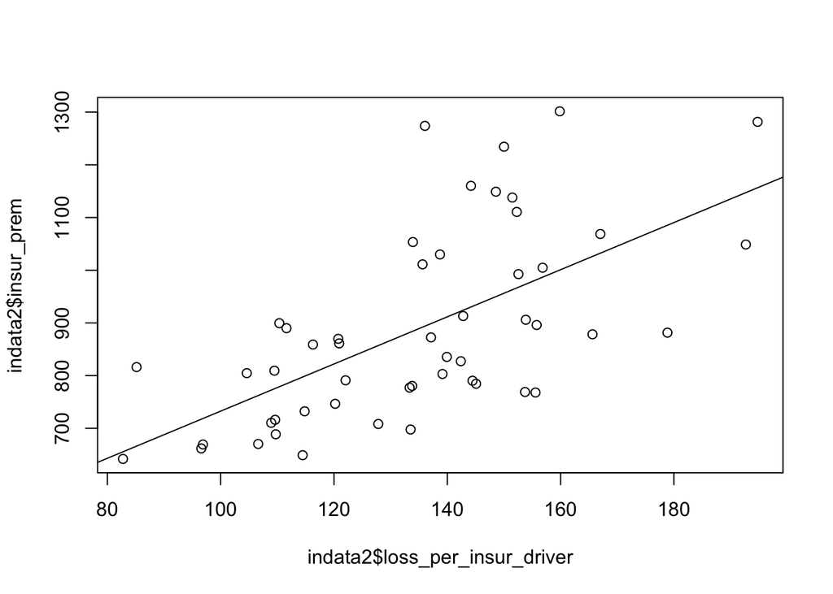

```r
plot(indata2$insur_prem ~ indata2$loss_per_insur_driver)
abline(linreg2)
```

```r
cor( indata2$insur_prem, indata2$loss_per_insur_driver)
```

```
## [1] 0.6231164
```

#### Insights:

For every Dollar increase in losses incurred by the insurance companies the insurance premimum goes up by $4.4733 and around 38.83% of the variance found in the response variable “Insurance premium” (insur_prem) can be explained by this predictor variable “Losses incurred by insurance companies for collisions per insured driver” (loss_per_insur_driver). There is a moderate positive linear relationship between the two variables.

## 5. Conclusion

From my data analysis of Bad Drivers Dataset, I found out that the top 3 states with highest number of drivers involved in fatal collisions per billion miles are North Dakota, South Carolina and West Virgina. The Analysis also shows that speeding is not the top reason for fatal collisions in the either of those 3 states. Instead, Hawaii is the state with maximum number of collisions due to speeding. Talking about changes in auto insurance premiums, for every dollar increase in losses incurred by insurance companies, the premium goes up by $4.5. Another thing that I found out with this analysis is if the number of drivers who are involved in a fatal collision per billion miles increase then the Insurance premium decreases by around $8.64. This sounds a bit odd so a deeper research and analysing other data sets in this field might give more accurate results.

## 6. References

Data source: https://github.com/fivethirtyeight/data/tree/master/bad-drivers

Picture source: https://en.wikipedia.org/wiki/Transportation_in_the_San_Francisco_Bay_Area#/media/File:I-80_Eastshore_Fwy.jpg